# Template Laporan Tugas Mingguan Lab IF540 Genap2223

## TUGAS LAB IF540 MACHINE LEARNING

### WEEK 07 : Klasifikasi Bayes dan Support Vector

#### Semester Genap 2022/2023

```python
# Run this code when you restart the machine
# Fill in with YOUR name and NIM
import datetime
import uuid

myName = "Christopher Darren"
myNIM = "00000054804"
```

```python
myDate = datetime.datetime.now()
myDevice = str(uuid.uuid1())

print("Name: \t\t{}".format(myName))
print("NIM: \t\t{}".format(myNIM))
print("Start: \t\t{}".format(myDate))
print("Device ID: \t{}".format(myDevice))
```

```
Name: 		Christopher Darren
NIM: 		00000054804
Start: 		2023-03-25 19:42:03.151451
Device ID: 	716e3b93-cb0a-11ed-a721-f02f74a116e8
```

### Dataset yang dipakai:

1. Twitter analysis – sumber : https://www.kaggle.com/datasets/arkhoshghalb/twitter-sentiment-analysis-hatred-speech?select=train.csv

### Hasil kerja

#### Importing system library

```python
import sys
```

#### Importing numpy library

```python
import numpy as np
```

## NAÏVE BAYES CLASSIFIER

### Naïve Bayes are a group of extremely fast and simple classification algorithms that are often suitable for very – high dimensional datasets

#### 1. Begin with standard imports

```python
%matplotlib inline
import numpy as np
import matplotlib.pyplot as plt
import seaborn as sns; sns.set()
```

#### 2. Generate Gaussian Naïve Bayes

#### Perhaps the easiest naive Bayes classifier to understand is Gaussian naive Bayes. In this classifier, the assumption is that data from each label is drawn from a simple Gaussian distribution.

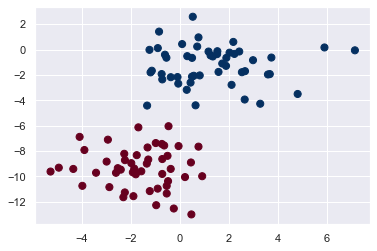

```python
from sklearn.datasets import make_blobs
X, y = make_blobs(100,2, centers=2, random_state=2, cluster_std=1.5)
plt.scatter(X[:,0], X[:,1], c=y, s=50, cmap='RdBu')
```

#### The result of this naive Gaussian assumption is shown in the following figure which is generate with the following code.

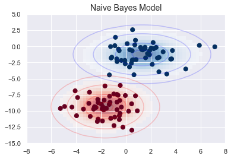

```python
from sklearn.datasets import make_blobs
X, y = make_blobs(100, 2, centers=2, random_state=2, cluster_std=1.5)

fig, ax = plt.subplots()

ax.scatter(X[:,0], X[:, 1], c=y, s=50, cmap='RdBu')
ax.set_title('Naive Bayes Model', size=14)

xlim= (-8, 8)
ylim = (-15, 5)

xg = np.linspace(xlim[0], xlim[1], 60)
yg = np.linspace(ylim[0], ylim[1], 40)
xx, yy = np.meshgrid(xg, yg)
Xgrid = np.vstack([xx.ravel(), yy.ravel()]).T

for label, color in enumerate(['red','blue']):
    mask = (y == label)
    mu, std = X[mask].mean(0), X[mask].std(0)
    P = np.exp(-0.5 * (Xgrid - mu) ** 2 / std ** 2).prod(1)
    Pm = np.ma.masked_array(P, P < 0.03)
    ax.pcolorfast(xg, yg, Pm.reshape(xx.shape), alpha=0.5,
                 cmap=color.title() + 's')
    ax.contour(xx, yy, P.reshape(xx.shape),
              levels=[0.01, 0.1, 0.5, 0.9],
              colors= color, alpha=0.2)

    ax.set(xlim=xlim, ylim=ylim)
```

#### 3. Implement GaussianNB with Scikit-Learn’s :

```python
from sklearn.naive_bayes import GaussianNB
model = GaussianNB()
model.fit(X, y)
```

```
GaussianNB()
```

#### 4. Now let’s generate some new data and predict the label

```python
rng= np.random.RandomState(0)
Xnew=[-6, -14]+[14, 18]*rng.rand(2000, 2)
ynew= model.predict(Xnew)
```

#### 5. Now, we can plot this new data to get an idea of where the decision boundary is

```
(-5.890554373486014,
 7.777566725032841,
 -13.775943665162341,
 3.3634536696825847)
```

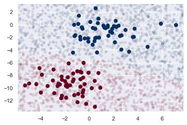

```python
plt.scatter(X[:,0], X[:,1], c=y, s=50, cmap='RdBu')
lim=plt.axis()
plt.scatter(Xnew[:,0], Xnew[:,1], c=ynew, s=20, cmap='RdBu', alpha=0.1)
plt.axis(lim)
```

#### 6. A nice piece of this Bayesian formalism is that it naturally allows for probabilistic classification, which we can compute using the predict_proba method.

```python
yprob = model.predict_proba(Xnew)
yprob[-8:].round(2)
```

```
array([[0.89, 0.11],
       [1.  , 0.  ],
       [1.  , 0.  ],
       [1.  , 0.  ],
       [1.  , 0.  ],
       [1.  , 0.  ],
       [0.  , 1.  ],
       [0.15, 0.85]])
```

### MULTINOMIAL NAÏVE BAYES

#### The Gaussian assumption just described is by no means the only simple assumption that could be used to specify the generative distribution for each label. Another useful example is multinomial naive Bayes, where the features are assumed to be generated from a simple multinomial distribution.

#### 7. Download the data and take a look the target names

```python
from sklearn.datasets import fetch_20newsgroups
data=fetch_20newsgroups()
data.target_names
```

```
['alt.atheism',
 'comp.graphics',
 'comp.os.ms-windows.misc',
 'comp.sys.ibm.pc.hardware',
 'comp.sys.mac.hardware',
 'comp.windows.x',
 'misc.forsale',
 'rec.autos',
 'rec.motorcycles',
 'rec.sport.baseball',
 'rec.sport.hockey',
 'sci.crypt',
 'sci.electronics',
 'sci.med',
 'sci.space',
 'soc.religion.christian',
 'talk.politics.guns',
 'talk.politics.mideast',
 'talk.politics.misc',
 'talk.religion.misc']
```

#### 8. For simplicity here, we will select just a few of these categories and download the training and testing set

```python
categories =['talk.religion.misc' ,'soc.religion.christian',
             'sci.space','comp.graphics']
train = fetch_20newsgroups(subset='train', categories=categories)
test = fetch_20newsgroups(subset='test', categories=categories)
```

#### 9. The representative entry from the data (5 first data)

```python
print(train.data[5])
```

```
From: dmcgee@uluhe.soest.hawaii.edu (Don McGee)
Subject: Federal Hearing
Originator: dmcgee@uluhe
Organization: School of Ocean and Earth Science and Technology
Distribution: usa
Lines: 10


Fact or rumor....?  Madalyn Murray O'Hare an atheist who eliminated the
use of the bible reading and prayer in public schools 15 years ago is now
going to appear before the FCC with a petition to stop the reading of the
Gospel on the airways of America.  And she is also campaigning to remove
Christmas programs, songs, etc from the public schools.  If it is true
then mail to Federal Communications Commission 1919 H Street Washington DC
20054 expressing your opposition to her request.  Reference Petition number

2493.
```

#### 10. In order to use this data for machine learning, we need to be able to convert the content of string into a vector of number. Use the TF-IDF vectorizer and create a pipeline that attaches it to a multinomial Naïve Bayes Classifier

```python
from sklearn.feature_extraction.text import TfidfVectorizer
from sklearn.naive_bayes import MultinomialNB
from sklearn.pipeline import make_pipeline

model = make_pipeline(TfidfVectorizer(), MultinomialNB())
```

#### 11. With this pipeline, we can apply the model to the training data and predict labels for the test data

```python
model.fit(train.data, train.target)
labels = model.predict(test.data)
```

#### 12. Now that we have predicted the labels for the test data, we can evaluate them to learn about the performance of the estimator. For the example, here is the confusion matrix between the true and predicted labels for the test data.

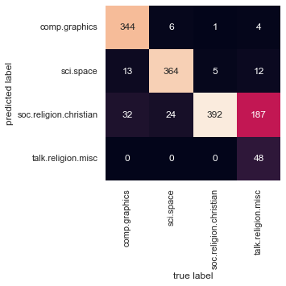

```python
from sklearn.metrics import confusion_matrix
mat = confusion_matrix(test.target, labels)
sns.heatmap(mat.T, square=True, annot=True, fmt='d', cbar=False,
           xticklabels=train.target_names, yticklabels=train.target_names)
plt.xlabel('true label')
plt.ylabel('predicted label');
```

```python
#predict_category = reg.predict(x)
```

```python
#categories('sending a payload to the ISS')
```

```python
#predict_category('discussing islam vs atheism')
```

```python
#predict_category('deterining the screen resolution')
```

## SUPPORT VECTOR MACHINE (SVM)

#### SVM are an extension that allows for more complex models that are not defined simply by hyperplanes in the input space.

#### 14. We begin with the standard import :

```python
%matplotlib inline
import numpy as np
import matplotlib.pyplot as plt
from scipy import stats

# use seaborn plotting defaults
import seaborn as sns; sns.set()
```

#### 15. As an example of this, consider the simple case of a classification task, in which the two classes are well separated :

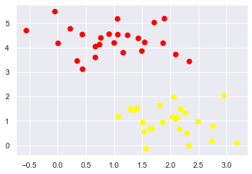

```python
from sklearn.datasets import make_blobs
X, y = make_blobs(n_samples=50, centers=2,
                 random_state=0, cluster_std=0.60)
plt.scatter(X[:, 0], X[:, 1], c=y, s=50, cmap='autumn');
```

#### 16. We can draw them as follows :

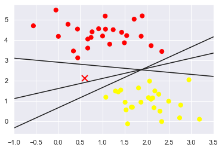

```python
xfit = np.linspace(-1, 3.5)
plt.scatter(X[:, 0], X[:,1], c=y , s=50, cmap='autumn')
plt.plot([0.6], [2.1], 'x', color='red', markeredgewidth=2, markersize=10)

for m, b in [(1, 0.65), (0.5, 1.6), (-0.2, 2.9)]:
    plt.plot(xfit, m * xfit + b, '-k')

plt.xlim(-1, 3.5);
```

#### Support Vector Machines : maximizing the Margin

#### 17. SVM offer one way to improve on this. The intuition is this : rather than simply drawing a zero – width line between the class, we can draw around each line a margin of some width, up to the nearest point. Here is an example this might look:

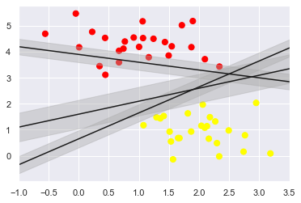

```python
xfit = np.linspace (-1, 3.5)
plt.scatter(X[:, 0], X[:, 1], c=y, s=50, cmap='autumn')

for m, b, d in[(1, 0.65, 0.33), (0.5, 1.6, 0.55), (-0.3, 3.9, 0.3)]:
    yfit = m * xfit + b
    plt.plot(xfit, yfit, '-k')
    plt.fill_between(xfit, yfit - d, yfit + d, edgecolor='none',
                    color='#AAAAAA', alpha=0.4)

plt.xlim(-1, 3.5);
```

#### Fitting a Support Vector Machine

#### 18. Let's see the result of an actual fit to this data: we will use Scikit-Learn's support vector classifier to train an SVM model on this data. For the time being, we will use a linear kernel and set the C parameter to a very large number.

```python
from sklearn.svm import SVC # "Support vector classifier"
model = SVC(kernel='linear' ,C=1E10)
model.fit(X, y)
```

```
SVC(C=10000000000.0, kernel='linear')
```

#### 19. To better visualize what's happening here, let's create a quick convenience function that will plot SVM decision boundaries for us:

```python
def plot_svc_decision_function(model, ax=None, plot_support=True):

    if ax is None:
        ax = plt.gca()
    xlim = ax.get_xlim()
    ylim = ax.get_ylim()

    x = np.linspace(xlim[0], xlim[1], 30)
    y = np.linspace(ylim[0], ylim[1], 30)
    Y, X = np.meshgrid(y, x)
    xy = np.vstack([X.ravel(), Y.ravel()]).T
    P = model.decision_function(xy).reshape(X.shape)

    ax.contour(X, Y, P, colors='k',
               levels = [-1, 0, 1], alpha=0.5,
               linestyles=['--', '-', '--'])

    if plot_support:
        ax.scatter(model.support_vectors_[:, 0],
                   model.support_vectors_[:, 1],
                   s=300, linewidth=1, facecolors='none')

    ax.set_xlim(xlim)
    ax.set_ylim(ylim)
```

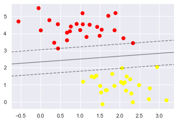

```python
plt.scatter(X[:, 0], X[:, 1], c=y ,s=50, cmap='autumn')
plot_svc_decision_function(model)
```

#### 20. In Scikit-Learn, the identity of these points are stored in the support*vectors* attribute of the classifier:

```python
model.support_vectors_
```

```
array([[0.44359863, 3.11530945],
       [2.33812285, 3.43116792],
       [2.06156753, 1.96918596]])
```

#### 21. We can see this, for example, if we plot the model learned from the first 60 points and first 120 points of this dataset:

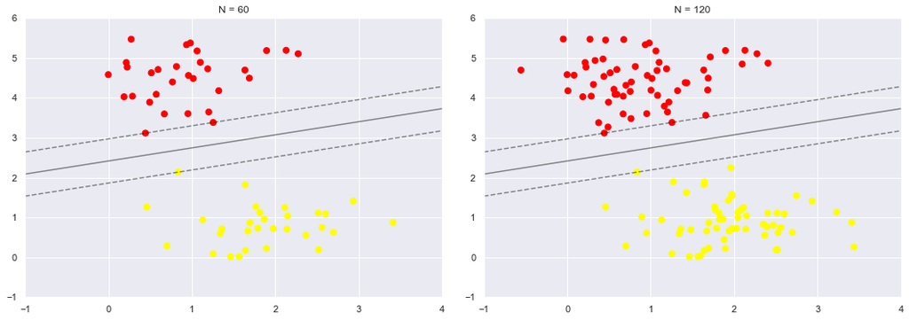

```python
def plot_svm(N=10, ax=None):
    X, y = make_blobs(n_samples=200, centers=2, random_state=0, cluster_std=0.6)

    X = X[:N]
    y = y[:N]

    model = SVC(kernel='linear', C=1E10)
    model.fit(X, y)

    ax = ax or plt.gca()
    ax.scatter(X[:, 0], X[:, 1], c=y, s=50, cmap='autumn')
    ax.set_xlim(-1, 4)
    ax.set_ylim(-1, 6)
    plot_svc_decision_function(model, ax)

fig, ax = plt.subplots(1, 2, figsize=(16, 6))
fig.subplots_adjust(left = 0.0625, right=0.95, wspace=0.1)
for axi, N in zip(ax, [60, 120]):
    plot_svm(N, axi)
    axi.set_title('N = {0}'.format(N))
```

#### 22. If we are running this notebook live, you can use IPython's interactive widgets to view this feature of the SVM model interactively:

```python
from ipywidgets import interact, fixed
interact(plot_svm, N=[10, 200], ax=fixed(None));
```

```
interactive(children=(Dropdown(description='N', options=(10, 200), value=10), Output()), _dom_classes=('widget…
```

#### 23. In SVM models, we can use a version of the same idea. To motivate the need for kernels, let's look at some data that is not linearly separable:

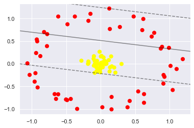

```python
from sklearn.datasets import make_circles
X, y = make_circles(100, factor=.1, noise=.1)

clf = SVC(kernel='linear').fit(X, y)

plt.scatter(X[:, 0], X[:, 1], c=y, s=50, cmap='autumn')
plot_svc_decision_function(clf, plot_support=False);
```

#### 24. For example, one simple projection we could use would be to compute a radial basis function centered on the middle clump:

```python
r = np.exp(-(X ** 2).sum(1))
```

#### 25. We can visualize this extra data dimension using a three-dimensional plot—if you are running this notebook live, you will be able to use the sliders to rotate the plot:

```python
from mpl_toolkits import mplot3d

def plot_3D(elev=30, azim=30, X=X, y=y):
    ax = plt.subplot(projection='3d')
    ax.scatter3D(X[:, 0], X[:, 1], r, c=y, s=50, cmap='autumn')
    ax.view_init(elev=elev, azim=azim)
    ax.set_xlabel('x')
    ax.set_ylabel('y')
    ax.set_zlabel('r')

interact(plot_3D, elev=[-90, 90], azip=(-180, 180),
        X=fixed(X), y=fixed(y));
```

```
interactive(children=(Dropdown(description='elev', options=(-90, 90), value=-90), IntSlider(value=30, descript…
```

### 26. In Scikit-Learn, we can apply kernelized SVM simply by changing our linear kernel to an RBF (radial basis function) kernel, using the kernel model hyperparameter:

```python
clf = SVC(kernel='rbf', C=1E6)
clf.fit(X, y)
```

```
SVC(C=1000000.0)
```

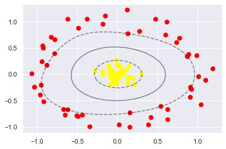

```python
plt.scatter(X[:, 0], X[:, 1], c=y, s=50, cmap='autumn')
plot_svc_decision_function(clf)
plt.scatter(clf.support_vectors_[:, 0], clf.support_vectors_[:, 1],
           s=300, lw=1, facecolors='none');
```

#### Using this kernelized support vector machine, we learn a suitable nonlinear decision boundary.This kernel transformation strategy is used often in machine learning to turn fast linear methods into fast nonlinear methods, especially for models in which the kernel trick can be used.

### Tuning the SVM : Softening Margins

#### 27. Our discussion thus far has centered around very clean datasets, in which a perfect decision boundary exists. But what if your data has some amount of overlap? For example, you may have data like this:

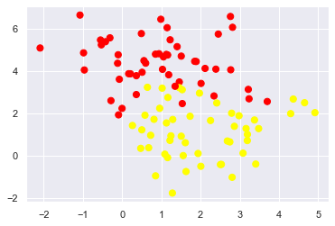

```python
X, y = make_blobs(n_samples=100, centers=2,
                 random_state=0, cluster_std=1.2)
plt.scatter(X[:, 0], X[:, 1], c=y, s=50, cmap='autumn');
```

### 28. The plot shown below gives a visual picture of how a changing C parameter affects the final fit, via the softening of the margin:

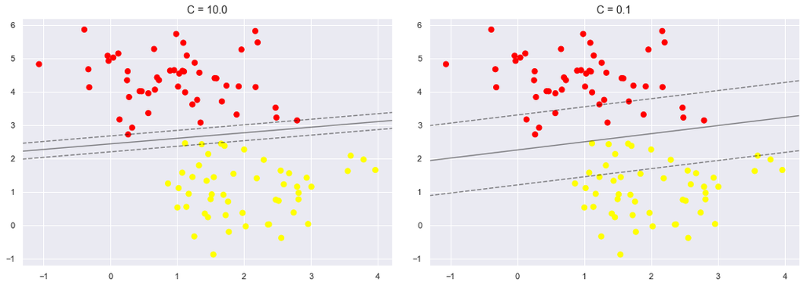

```python
X, y = make_blobs(n_samples=100, centers=2, random_state=0, cluster_std=0.8)

fig, ax = plt.subplots(1, 2, figsize=(16,6))
fig.subplots_adjust(left=0.0625, right=0.95, wspace=0.1)

for axi, C in zip(ax, [10.0, 0.1]):
    model = SVC(kernel='linear', C=C).fit(X,y)
    axi.scatter(X[:, 0], X[:, 1], c=y, s=50, cmap='autumn')
    plot_svc_decision_function(model, axi)
    axi.scatter(model.support_vectors_[:, 0],
               model.support_vectors_[:, 1],
               s=100, lw=1, facecolors='none');
    axi.set_title('C = {0:.1f}'.format(C), size=14)
```

### Example : Face Recognition

#### 29. As an example of support vector machines in action, let's take a look at the facial recognition problem. We will use the Labeled Faces in the Wild dataset, which consists of several thousand collated photos of various public figures. A fetcher for the dataset is built into Scikit-Learn:

```python
from sklearn.datasets import fetch_lfw_people
faces = fetch_lfw_people(min_faces_per_person=60)
print(faces.target_names)
print(faces.images.shape)
```

```
['Ariel Sharon' 'Colin Powell' 'Donald Rumsfeld' 'George W Bush'
 'Gerhard Schroeder' 'Hugo Chavez' 'Junichiro Koizumi' 'Tony Blair']
(1348, 62, 47)
```

#### 30. Let's plot a few of these faces to see what we're working with:

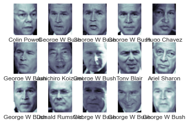

```python
fig, ax = plt.subplots(3, 5)
for i, axi in enumerate(ax.flat):
    axi.imshow(faces.images[i], cmap='bone')
    axi.set(xticks=[], yticks=[],
           xlabel=faces.target_names[faces.target[i]])
```

#### 31. Each image contains [62×47] or nearly 3,000 pixels. We could proceed by simply using each pixel value as a feature, but often it is more effective to use some sort of preprocessor to extract more meaningful features; here we will use a principal component analysis (PCA) to extract 150 fundamental components to feed into our support vector machine classifier. We can do this most straightforwardly by packaging the preprocessor and the classifier into a single pipeline:

```python
from sklearn.svm import SVC
from sklearn.decomposition import PCA as RandomizedPCA
from sklearn.pipeline import make_pipeline

pca= RandomizedPCA(n_components=150, whiten=True, random_state=42)
svc = SVC(kernel='rbf', class_weight='balanced')
model = make_pipeline(pca, svc)
```

#### 32. For the sake of testing our classifier output, we will split the data into a training and testing set:

```python
from sklearn.model_selection import train_test_split
Xtrain, Xtest, ytrain, ytest = train_test_split(faces.data, faces.target,
                                               random_state=42)
```

#### 33. Finally, we can use a grid search cross-validation to explore combinations of parameters.Here we will adjust C (which controls the margin hardness) and gamma (which controls the size of the radial basis function kernel), and determine the best model:

```python
from sklearn.model_selection import GridSearchCV
param_grid = {'svc__C':[1, 5, 10, 50],
             'svc__gamma': [0.0001, 0.0005, 0.001, 0.005]}
grid = GridSearchCV(model, param_grid)

%time grid.fit(Xtrain, ytrain)
print(grid.best_params_)
```

```
CPU times: total: 1min 47s
Wall time: 18 s
{'svc__C': 10, 'svc__gamma': 0.001}
```

#### 34. Now with this cross-validated model, we can predict the labels for the test data, which the model has not yet seen:

```python
model = grid.best_estimator_
yfit = model.predict(Xtest)
```

#### 35. Let's take a look at a few of the test images along with their predicted values:

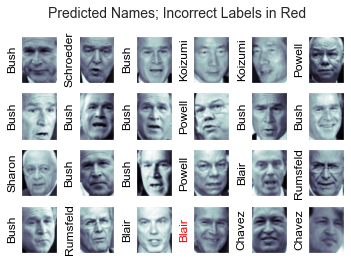

```python
fig, ax = plt.subplots(4, 6)
for i, axi in enumerate(ax.flat):
    axi.imshow(Xtest[i].reshape(62, 47), cmap='bone')
    axi.set(xticks=[], yticks=[])
    axi.set_ylabel(faces.target_names[yfit[i]].split()[-1],
                  color='black' if yfit[i] == ytest[i] else 'red')
fig.suptitle('Predicted Names; Incorrect Labels in Red', size=14);
```

#### 36. Out of this small sample, our optimal estimator mislabeled only a single face (Bush’s face in the bottom row was mislabeled as Blair). We can get a better sense of our estimator's performance using the classification report, which lists recovery statistics label by label:

```python
from sklearn.metrics import classification_report
print(classification_report(ytest, yfit,
                           target_names=faces.target_names))
```

```
                   precision    recall  f1-score   support

     Ariel Sharon       0.65      0.73      0.69        15
     Colin Powell       0.80      0.87      0.83        68
  Donald Rumsfeld       0.74      0.84      0.79        31
    George W Bush       0.92      0.83      0.88       126
Gerhard Schroeder       0.86      0.83      0.84        23
      Hugo Chavez       0.93      0.70      0.80        20
Junichiro Koizumi       0.92      1.00      0.96        12
       Tony Blair       0.85      0.95      0.90        42

         accuracy                           0.85       337
        macro avg       0.83      0.84      0.84       337
     weighted avg       0.86      0.85      0.85       337
```

#### 37. We might also display the confusion matrix between these classes:

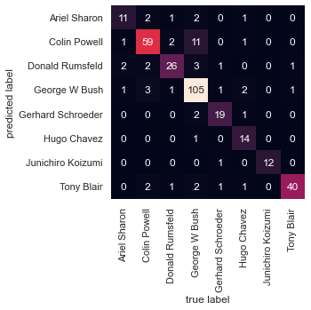

```python
from sklearn.metrics import confusion_matrix
mat = confusion_matrix(ytest, yfit)
sns.heatmap(mat.T, square=True, annot=True, fmt='d', cbar=False,
           xticklabels=faces.target_names,
           yticklabels=faces.target_names)

plt.xlabel('true label')
plt.ylabel('predicted label');
```

# ---------Dataset sendiri-----------

##### generate gaussian naive bayes sendiri

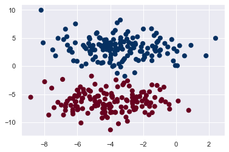

```python
from sklearn.datasets import make_blobs
X, y = make_blobs(300,2, centers=2, random_state=60, cluster_std=1.8)
plt.scatter(X[:,0], X[:,1], c=y, s=50, cmap='RdBu')
```

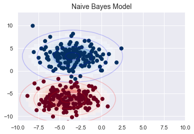

```python
#from sklearn.datasets import make_blobs
#X, y = make_blobs(300, 2, centers=2, random_state=60, cluster_std=1.8)

fig, ax = plt.subplots()

ax.scatter(X[:,0], X[:, 1], c=y, s=50, cmap='RdBu')
ax.set_title('Naive Bayes Model', size=14)

xlim= (-10, 10)
ylim = (-11, 13)

xg = np.linspace(xlim[0], xlim[1], 60)
yg = np.linspace(ylim[0], ylim[1], 40)
xx, yy = np.meshgrid(xg, yg)
Xgrid = np.vstack([xx.ravel(), yy.ravel()]).T

for label, color in enumerate(['red','blue']):
    mask = (y == label)
    mu, std = X[mask].mean(0), X[mask].std(0)
    P = np.exp(-0.5 * (Xgrid - mu) ** 2 / std ** 2).prod(1)
    Pm = np.ma.masked_array(P, P < 0.03)
    ax.pcolorfast(xg, yg, Pm.reshape(xx.shape), alpha=0.5,
                 cmap=color.title() + 's')
    ax.contour(xx, yy, P.reshape(xx.shape),
              levels=[0.01, 0.1, 0.5, 0.9],
              colors= color, alpha=0.2)

    ax.set(xlim=xlim, ylim=ylim)
```

```python
from sklearn.naive_bayes import GaussianNB
model = GaussianNB()
model.fit(X, y)
```

```
GaussianNB()
```

##### Now let’s generate some new data and predict the label

```python
rng= np.random.RandomState(0)
Xnew=[-15, -20]+[40, 45]*rng.rand(1500, 2)
ynew= model.predict(Xnew)
```

##### plotting the scatter plot

```
(-9.393329897741664, 2.955833711204949, -12.38824983899076, 11.004997296595723)
```

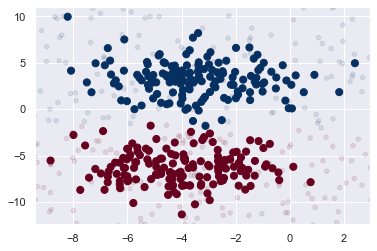

```python
plt.scatter(X[:,0], X[:,1], c=y, s=50, cmap='RdBu')
lim=plt.axis()
plt.scatter(Xnew[:,0], Xnew[:,1], c=ynew, s=20, cmap='RdBu', alpha=0.1)
plt.axis(lim)
```

```python
#new dataset probalistic

yprob = model.predict_proba(Xnew)
yprob[-8:].round(2)
```

```
array([[0., 1.],
       [1., 0.],
       [0., 1.],
       [0., 1.],
       [0., 1.],
       [0., 1.],
       [1., 0.],
       [0., 1.]])
```

### MULTINOMIAL NAÏVE BAYES (Dataset Sendiri)

#### Importing dataset from kaggle

```python
import pandas as pd
import numpy as np
```

```python
sentimenAny = pd.read_csv(r"D:\SEMESTER 4\IF540 Machine Learning\LAB\week7\train.csv")
sentimenAny
```

|  | id | label | tweet |
| --- | --- | --- | --- |
| 0 | 1 | 0 | @user when a father is dysfunctional and is s... |
| 1 | 2 | 0 | @user @user thanks for #lyft credit i can't us... |
| 2 | 3 | 0 | bihday your majesty |
| 3 | 4 | 0 | #model i love u take with u all the time in ... |
| 4 | 5 | 0 | factsguide: society now #motivation |
| ... | ... | ... | ... |
| 31957 | 31958 | 0 | ate @user isz that youuu?ðððððð... |
| 31958 | 31959 | 0 | to see nina turner on the airwaves trying to... |
| 31959 | 31960 | 0 | listening to sad songs on a monday morning otw... |
| 31960 | 31961 | 1 | @user #sikh #temple vandalised in in #calgary,... |
| 31961 | 31962 | 0 | thank you @user for you follow |

31962 rows × 3 columns

```python
sentimenAny.columns
```

```
Index(['id', 'label', 'tweet'], dtype='object')
```

```python
sentimenAny = pd.read_csv(r"D:\SEMESTER 4\IF540 Machine Learning\LAB\week7\train.csv").iloc[:, :3]
#sentimenAny.columns =['id','label','tweet']
sentimenAny.head(2)
```

|  | id | label | tweet |
| --- | --- | --- | --- |
| 0 | 1 | 0 | @user when a father is dysfunctional and is s... |
| 1 | 2 | 0 | @user @user thanks for #lyft credit i can't us... |

```python
sentimenAny =sentimenAny.iloc[:, [2,1,0]]
sentimenAny
```

|  | tweet | label | id |
| --- | --- | --- | --- |
| 0 | @user when a father is dysfunctional and is s... | 0 | 1 |
| 1 | @user @user thanks for #lyft credit i can't us... | 0 | 2 |
| 2 | bihday your majesty | 0 | 3 |
| 3 | #model i love u take with u all the time in ... | 0 | 4 |
| 4 | factsguide: society now #motivation | 0 | 5 |
| ... | ... | ... | ... |
| 31957 | ate @user isz that youuu?ðððððð... | 0 | 31958 |
| 31958 | to see nina turner on the airwaves trying to... | 0 | 31959 |
| 31959 | listening to sad songs on a monday morning otw... | 0 | 31960 |
| 31960 | @user #sikh #temple vandalised in in #calgary,... | 1 | 31961 |
| 31961 | thank you @user for you follow | 0 | 31962 |

31962 rows × 3 columns

##### dropping 'id' column

```python
sentimenAny1 = sentimenAny.drop(['id'], axis=1)
sentimenAny1
```

|  | tweet | label |
| --- | --- | --- |
| 0 | @user when a father is dysfunctional and is s... | 0 |
| 1 | @user @user thanks for #lyft credit i can't us... | 0 |
| 2 | bihday your majesty | 0 |
| 3 | #model i love u take with u all the time in ... | 0 |
| 4 | factsguide: society now #motivation | 0 |
| ... | ... | ... |
| 31957 | ate @user isz that youuu?ðððððð... | 0 |
| 31958 | to see nina turner on the airwaves trying to... | 0 |
| 31959 | listening to sad songs on a monday morning otw... | 0 |
| 31960 | @user #sikh #temple vandalised in in #calgary,... | 1 |
| 31961 | thank you @user for you follow | 0 |

31962 rows × 2 columns

#### Train and splitting data

```python
X = sentimenAny1.iloc[:, 0]
y = sentimenAny1.iloc[:, -1]

from sklearn.model_selection import train_test_split
X_train, X_test, y_train, y_test = train_test_split(X, y , random_state=120)
```

#### TFID, Multinomial, and Pipeline

```python
from sklearn.feature_extraction.text import TfidfVectorizer
from sklearn.naive_bayes import MultinomialNB
from sklearn.pipeline import make_pipeline

model = make_pipeline(TfidfVectorizer(), MultinomialNB())
```

```python
model.fit(X_train, y_train)
sentimenAny1_predict = model.predict(X_test)
```

#### generate confusion matrix for own dataset

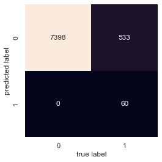

```python
from sklearn.metrics import confusion_matrix
mat = confusion_matrix(y_test, sentimenAny1_predict)
sns.heatmap(mat.T, square=True, annot=True, fmt='d', cbar=False)
plt.xlabel('true label')
plt.ylabel('predicted label');
```

## SUPPORT VECTOR MACHINE (SVM) own Dataset

#### 1. make blobs

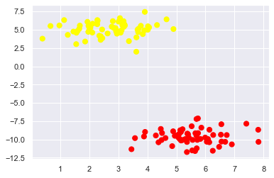

```python
from sklearn.datasets import make_blobs
X, y = make_blobs(n_samples=120, centers=2,
                 random_state=10, cluster_std=1)
plt.scatter(X[:, 0], X[:, 1], c=y, s=50, cmap='autumn');
```

#### drawing

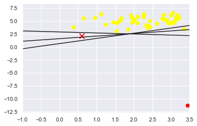

```python
xfit = np.linspace(-1, 3.5)
plt.scatter(X[:, 0], X[:,1], c=y , s=50, cmap='autumn')
plt.plot([0.6], [2.1], 'x', color='red', markeredgewidth=2, markersize=10)

for m, b in [(1, 0.65), (0.5, 1.6), (-0.2, 2.9)]:
    plt.plot(xfit, m * xfit + b, '-k')

plt.xlim(-1, 3.5);
```

### Support Vector Machines : maximizing the Margin for own dataset

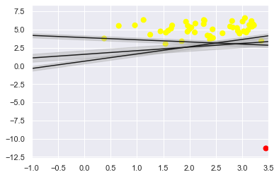

```python
xfit = np.linspace (-1, 3.5)
plt.scatter(X[:, 0], X[:, 1], c=y, s=50, cmap='autumn')

for m, b, d in[(1, 0.65, 0.33), (0.5, 1.6, 0.55), (-0.3, 3.9, 0.3)]:
    yfit = m * xfit + b
    plt.plot(xfit, yfit, '-k')
    plt.fill_between(xfit, yfit - d, yfit + d, edgecolor='none',
                    color='#AAAAAA', alpha=0.4)

plt.xlim(-1, 3.5);
```

#### fitting vector machine

```python
from sklearn.svm import SVC # "Support vector classifier"
model = SVC(kernel='linear' ,C=1E10)
model.fit(X, y)
```

```
SVC(C=10000000000.0, kernel='linear')
```

#### decision boundaries dataset

```python
def plot_svc_decision_function(model, ax=None, plot_support=True):

    if ax is None:
        ax = plt.gca()
    xlim = ax.get_xlim()
    ylim = ax.get_ylim()

    x = np.linspace(xlim[0], xlim[1], 30)
    y = np.linspace(ylim[0], ylim[1], 30)
    Y, X = np.meshgrid(y, x)
    xy = np.vstack([X.ravel(), Y.ravel()]).T
    P = model.decision_function(xy).reshape(X.shape)

    ax.contour(X, Y, P, colors='k',
               levels = [-1, 0, 1], alpha=0.5,
               linestyles=['--', '-', '--'])

    if plot_support:
        ax.scatter(model.support_vectors_[:, 0],
                   model.support_vectors_[:, 1],
                   s=300, linewidth=1, facecolors='none')

    ax.set_xlim(xlim)
    ax.set_ylim(ylim)
```

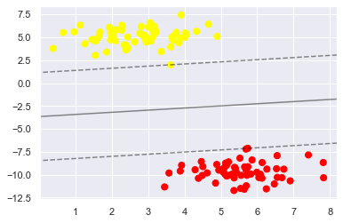

```python
plt.scatter(X[:, 0], X[:, 1], c=y ,s=50, cmap='autumn')
plot_svc_decision_function(model)
```

```python
model.support_vectors_
```

```
array([[ 5.74116664, -7.11730996],
       [ 3.61546511,  1.99648088]])
```

#### generate own data

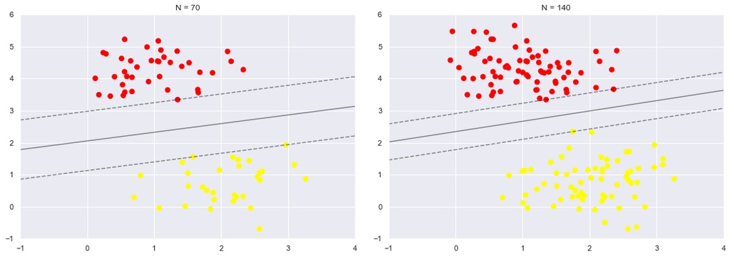

```python
def plot_svm(N=10, ax=None):
    X, y = make_blobs(n_samples=350, centers=2, random_state=0, cluster_std=0.6)

    X = X[:N]
    y = y[:N]

    model = SVC(kernel='linear', C=1E10)
    model.fit(X, y)

    ax = ax or plt.gca()
    ax.scatter(X[:, 0], X[:, 1], c=y, s=50, cmap='autumn')
    ax.set_xlim(-1, 4)
    ax.set_ylim(-1, 6)
    plot_svc_decision_function(model, ax)

fig, ax = plt.subplots(1, 2, figsize=(16, 6))
fig.subplots_adjust(left = 0.0625, right=0.95, wspace=0.1)
for axi, N in zip(ax, [70, 140]):
    plot_svm(N, axi)
    axi.set_title('N = {0}'.format(N))
```

#### interactive plot own dataset

```python
from ipywidgets import interact, fixed
interact(plot_svm, N=[10, 200], ax=fixed(None));
```

```
interactive(children=(Dropdown(description='N', options=(10, 200), value=10), Output()), _dom_classes=('widget…
```

### beyond boundaries: kernel SVM own

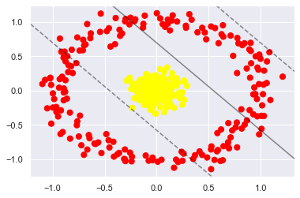

```python
from sklearn.datasets import make_circles
X, y = make_circles(400, factor=.1, noise=.1)

clf = SVC(kernel='linear').fit(X, y)

plt.scatter(X[:, 0], X[:, 1], c=y, s=50, cmap='autumn')
plot_svc_decision_function(clf, plot_support=False);
```

```python
#projection

r = np.exp(-(X ** 2).sum(1))
```

#### visualize again after projection

```python
from mpl_toolkits import mplot3d

def plot_3D(elev=30, azim=30, X=X, y=y):
    ax = plt.subplot(projection='3d')
    ax.scatter3D(X[:, 0], X[:, 1], r, c=y, s=50, cmap='autumn')
    ax.view_init(elev=elev, azim=azim)
    ax.set_xlabel('x')
    ax.set_ylabel('y')
    ax.set_zlabel('r')

interact(plot_3D, elev=[-90, 90], azip=(-180, 180),
        X=fixed(X), y=fixed(y));
```

```
interactive(children=(Dropdown(description='elev', options=(-90, 90), value=-90), IntSlider(value=30, descript…
```

#### SVM hyperparameter

```python
clf = SVC(kernel='rbf', C=1E6)
clf.fit(X, y)
```

```
SVC(C=1000000.0)
```

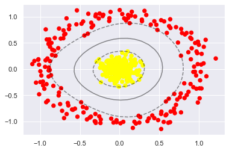

```python
plt.scatter(X[:, 0], X[:, 1], c=y, s=40, cmap='autumn')
plot_svc_decision_function(clf)
plt.scatter(clf.support_vectors_[:, 0], clf.support_vectors_[:, 1],
           s=400, lw=1, facecolors='none');
```

#### Tuning the SVM : Softening Margins

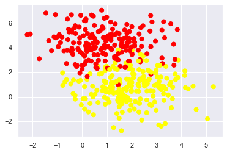

```python
X, y = make_blobs(n_samples=400, centers=2,
                 random_state=0, cluster_std=1.2)
plt.scatter(X[:, 0], X[:, 1], c=y, s=50, cmap='autumn');
```

#### C Paremeter Own

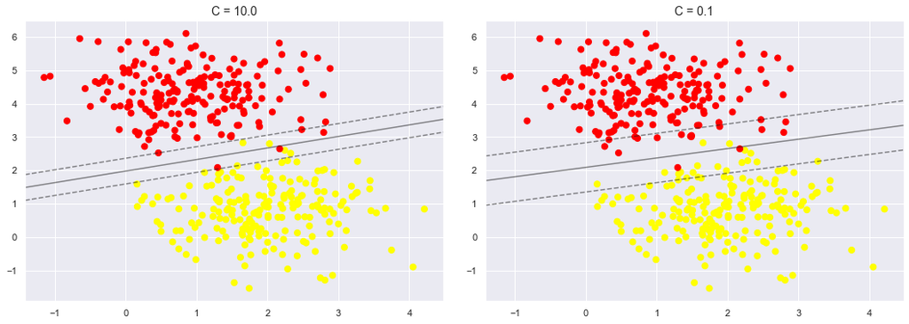

```python
X, y = make_blobs(n_samples=400, centers=2, random_state=0, cluster_std=0.8)

fig, ax = plt.subplots(1, 2, figsize=(16,6))
fig.subplots_adjust(left=0.0625, right=0.95, wspace=0.1)

for axi, C in zip(ax, [10.0, 0.1]):
    model = SVC(kernel='linear', C=C).fit(X,y)
    axi.scatter(X[:, 0], X[:, 1], c=y, s=50, cmap='autumn')
    plot_svc_decision_function(model, axi)
    axi.scatter(model.support_vectors_[:, 0],
               model.support_vectors_[:, 1],
               s=100, lw=1, facecolors='none');
    axi.set_title('C = {0:.1f}'.format(C), size=14)
```

### Face recognition generate own

```python
from sklearn.datasets import fetch_lfw_people
faces = fetch_lfw_people(min_faces_per_person=30)
print(faces.target_names)
print(faces.images.shape)
```

```
['Alejandro Toledo' 'Alvaro Uribe' 'Andre Agassi' 'Ariel Sharon'
 'Arnold Schwarzenegger' 'Colin Powell' 'David Beckham' 'Donald Rumsfeld'
 'George W Bush' 'Gerhard Schroeder' 'Gloria Macapagal Arroyo'
 'Guillermo Coria' 'Hans Blix' 'Hugo Chavez' 'Jacques Chirac'
 'Jean Chretien' 'Jennifer Capriati' 'John Ashcroft' 'John Negroponte'
 'Junichiro Koizumi' 'Kofi Annan' 'Laura Bush' 'Lleyton Hewitt'
 'Luiz Inacio Lula da Silva' 'Megawati Sukarnoputri' 'Nestor Kirchner'
 'Recep Tayyip Erdogan' 'Roh Moo-hyun' 'Serena Williams'
 'Silvio Berlusconi' 'Tom Ridge' 'Tony Blair' 'Vicente Fox'
 'Vladimir Putin']
(2370, 62, 47)
```

### plot visualization

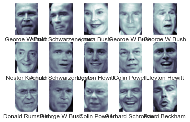

```python
fig, ax = plt.subplots(3, 5)
for i, axi in enumerate(ax.flat):
    axi.imshow(faces.images[i], cmap='bone')
    axi.set(xticks=[], yticks=[],
           xlabel=faces.target_names[faces.target[i]])
```

### PCA own

```python
from sklearn.svm import SVC
from sklearn.decomposition import PCA as RandomizedPCA
from sklearn.pipeline import make_pipeline

pca= RandomizedPCA(n_components=150, whiten=True, random_state=42)
svc = SVC(kernel='rbf', class_weight='balanced')
model = make_pipeline(pca, svc)
```

#### splitting again

```python
from sklearn.model_selection import train_test_split
Xtrain, Xtest, ytrain, ytest = train_test_split(faces.data, faces.target,
                                               random_state=62)
```

##### GSCV for C Parameters

```python
from sklearn.model_selection import GridSearchCV
param_grid = {'svc__C':[1, 5, 10, 50],
             'svc__gamma': [0.0001, 0.0005, 0.001, 0.005]}
grid = GridSearchCV(model, param_grid)

%time grid.fit(Xtrain, ytrain)
print(grid.best_params_)
```

```
CPU times: total: 3min 41s
Wall time: 54.3 s
{'svc__C': 10, 'svc__gamma': 0.001}
```

```python
model = grid.best_estimator_
yfit = model.predict(Xtest)
```

#### visualisasi model best estimator

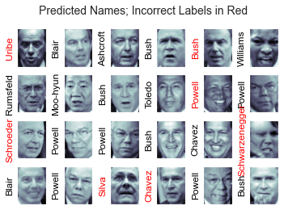

```python
fig, ax = plt.subplots(4, 6)
for i, axi in enumerate(ax.flat):
    axi.imshow(Xtest[i].reshape(62, 47), cmap='bone')
    axi.set(xticks=[], yticks=[])
    axi.set_ylabel(faces.target_names[yfit[i]].split()[-1],
                  color='black' if yfit[i] == ytest[i] else 'red')
fig.suptitle('Predicted Names; Incorrect Labels in Red', size=14);
```

#### classification report for own generate data

```python
from sklearn.metrics import classification_report
print(classification_report(ytest, yfit,
                           target_names=faces.target_names))
```

```
                           precision    recall  f1-score   support

         Alejandro Toledo       0.57      0.40      0.47        10
             Alvaro Uribe       0.67      0.67      0.67         6
             Andre Agassi       0.50      0.38      0.43         8
             Ariel Sharon       0.58      0.79      0.67        14
    Arnold Schwarzenegger       0.33      0.30      0.32        10
             Colin Powell       0.79      0.79      0.79        72
            David Beckham       0.57      0.80      0.67         5
          Donald Rumsfeld       0.64      0.77      0.70        39
            George W Bush       0.79      0.81      0.80       120
        Gerhard Schroeder       0.44      0.70      0.54        23
  Gloria Macapagal Arroyo       0.91      1.00      0.95        10
          Guillermo Coria       0.33      0.40      0.36         5
                Hans Blix       0.45      0.50      0.48        10
              Hugo Chavez       0.52      0.65      0.58        20
           Jacques Chirac       0.86      0.43      0.57        14
            Jean Chretien       0.73      0.84      0.78        19
        Jennifer Capriati       0.86      0.60      0.71        10
            John Ashcroft       0.73      0.53      0.62        15
          John Negroponte       0.57      0.40      0.47        10
        Junichiro Koizumi       0.78      0.78      0.78         9
               Kofi Annan       1.00      0.71      0.83         7
               Laura Bush       0.75      1.00      0.86         6
           Lleyton Hewitt       0.80      0.67      0.73        12
Luiz Inacio Lula da Silva       0.78      0.64      0.70        11
    Megawati Sukarnoputri       0.75      0.50      0.60         6
          Nestor Kirchner       1.00      0.50      0.67        10
     Recep Tayyip Erdogan       0.67      0.33      0.44         6
             Roh Moo-hyun       1.00      0.78      0.88         9
          Serena Williams       0.73      0.61      0.67        18
        Silvio Berlusconi       0.29      0.18      0.22        11
                Tom Ridge       0.80      0.57      0.67         7
               Tony Blair       0.71      0.79      0.75        43
              Vicente Fox       0.75      0.43      0.55         7
           Vladimir Putin       0.33      0.45      0.38        11

                 accuracy                           0.69       593
                macro avg       0.68      0.61      0.63       593
             weighted avg       0.70      0.69      0.69       593
```

#### confusion matrix for generate face data

[figure not shown]

```python
from sklearn.metrics import confusion_matrix
mat = confusion_matrix(ytest, yfit)
sns.heatmap(mat.T, square=True, annot=True, fmt='d', cbar=False,
           xticklabels=faces.target_names,
           yticklabels=faces.target_names)

plt.xlabel('true label')
plt.ylabel('predicted label');
```

### Kesimpulan

[output not shown]

```python
# Footer
myDate = datetime.datetime.now()
print("I certify that this is my own work.")
print("Signed by:")
print("Name: \t\t{}".format(myName))
print("NIM: \t\t{}".format(myNIM))
print("Time-stamp:\t{}".format(myDate))
```

```
I certify that this is my own work.
Signed by:
Name: 		Christopher Darren
NIM: 		00000054804
Time-stamp:	2023-03-28 10:37:08.253096
```

### Save the notebook, then convert the notebook to html (by running the next code).

```python
!jupyter nbconvert --to html "./Template Laporan Tugas Mingguan Lab IF540 Genap2223.ipynb" --output-dir="./"
```

```
[NbConvertApp] Converting notebook ./Template Laporan Tugas Mingguan Lab IF540 Genap2223.ipynb to html
[NbConvertApp] Writing 2908930 bytes to Template Laporan Tugas Mingguan Lab IF540 Genap2223.html
```